# Incubation times and symptom-based risk updates

## Implemented incubation model

The package describes time from infection to symptom onset among infected individuals who develop symptoms. Time is measured in days; infection occurs at time zero. A single known infection time and complete ascertainment of symptom onset are assumed. Incubation is distinct from the latent period (time to infectiousness). Neither transmission risk nor quarantine effectiveness follows from an incubation distribution alone.

Let $T$ have support $\mathcal{T}=(0,\infty)$ and let $\theta=(\mu,\sigma)$ be fixed model parameters. The implemented model is $\log T\sim N(\mu,\sigma^2)$, with density and cumulative distribution
$$f(t;\theta)=\frac{1}{t\sigma\sqrt{2\pi}}
\exp\left[-\frac{(\log t-\mu)^2}{2\sigma^2}\right],\qquad
F(t;\theta)=\mathrm{Pr}_{\mathcal{T}}(T\leq t;\theta)
=\Phi\left(\frac{\log t-\mu}{\sigma}\right).$$
For $t\leq0$, both density and cumulative probability are zero. The survival function is $S(t;\theta)=1-F(t;\theta)$ and $Q(p;\theta)=\exp\{\mu+\sigma\Phi^{-1}(p)\}$ for $0<p<1$. Thus the median is $e^\mu$, the mean is $\mathrm{E}_{\mathcal{T}}(T;\theta)=e^{\mu+\sigma^2/2}$, and $\sigma$ is a standard deviation on the log scale.

| Identifier | $\mu$ | $\sigma$ |
| --- | --- | --- |
| `lessler_2009` | 2.526 | 0.207 |
| `morgenstern_2026` | 2.62 | 0.23 |

The default agrees with the measles median (12.5 days) and dispersion factor (1.23) reported by Lessler et al. (2009). Dispersion here means $e^\sigma$. The alternative identifier and parameter values come from the original package implementation; a publication supporting that parameterization has not been established. Treat it as a sensitivity scenario, without assuming an independently validated symptom endpoint.

```r
library(quarantimer)
q_incubation(c(0.5, 0.95))
```

```
[1] 12.50339 17.57513
```

```r
p_incubation(14)
```

```
[1] 0.7075257
```

The density, CDF, quantile and simulation interfaces are respectively `d_incubation()`, `p_incubation()`, `q_incubation()`, and `r_incubation()`. They delegate to R’s lognormal functions. No parameters are fitted and parameter uncertainty is not propagated.

## Conditioning on continued absence of symptoms

Among individuals known to be infected and destined to develop symptoms, the probability of onset between days $t$ and $t+h$, given no onset by day $t$, is
$$\mathrm{Pr}_{\mathcal{T}}(t<T\leq t+h\mid T>t;\theta)
=\frac{F(t+h;\theta)-F(t;\theta)}{S(t;\theta)}.$$
This quantity differs from the probability that an exposed person is infected. For that question introduce $I\in\{0,1\}$ and a specified pre-observation infection probability $\pi$. Suppose every infected person eventually develops the modeled symptoms, uninfected people never develop those symptoms, and observation is perfect. Write $A_t$ for no symptoms by time $t$. Bayes’ rule then gives, on the joint support $\mathcal{Y}$ of infection and onset,
$$\mathrm{Pr}_{\mathcal{Y}}(I=1\mid A_t;\pi,\theta)
=\frac{\pi S(t;\theta)}{1-\pi+\pi S(t;\theta)}.$$
The denominator is the probability of the observed symptom-free history. The following is a transparent calculation using the package, not a fitted exposure model or a dedicated risk-update API.

```r
pi <- 0.1 # illustrative assumed infection probability
t <- 14
s <- 1 - p_incubation(t)
pi * s / (1 - pi + pi * s)
```

```
[1] 0.03147432
```

For extreme tails use `stats::plnorm(t, meanlog, sdlog, lower.tail = FALSE)` with parameters from `incubation_model()` to avoid subtractive cancellation. A nonzero asymptomatic fraction would change the likelihood of $A_t$; the displayed update would then be inappropriate without modification.

## Multiple contacts and additional evidence

For independent contacts with fixed prior probabilities $\pi_i$, define $r_i(t)$ by the preceding update. Conditional independence implies that the probability at least one remains infected is $1-\prod_i[1-r_i(t)]$. Shared uncertainty in source infectiousness generally makes contacts dependent, so this product cannot simply be used after marginalizing shared parameters.

An extended exposure model could specify $\pi_i=1-\exp(-\lambda w_i)$ with fixed exposure weights $w_i\geq0$ and unknown intensity $\lambda\geq0$. Under conditional independence, contacts with observed onset times $t_i$ contribute $\pi_i f(t_i;\theta)$ to a likelihood; contacts without symptoms through $c_i$ contribute $1-\pi_i+\pi_i S(c_i;\theta)$. This provides a route to updating shared exposure intensity as observations accumulate. These likelihood and exposure components are mathematical extensions, not implemented estimators.

Negative tests additionally require time-dependent test sensitivity, specificity, and assumptions about dependence between repeated tests and symptoms. Unknown exposure times require integrating over possible infection times. Infectiousness and onward transmission require a separate disease progression model. The current package supplies none of those components and does not optimize quarantine duration.

## Synthetic observations and visual checks

`incubation_example` contains 200 complete independent simulated incubation times from the default model. Generation uses seed 20260323 and is recorded in `data-raw/incubation_example.R`. These data illustrate the interface and test software behavior; agreement with the generating distribution is not external validation. Real observations with censoring or uncertain exposure times require appropriate likelihoods rather than a histogram of completed cases alone.

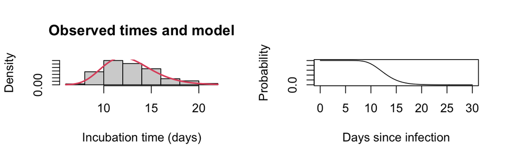

```r
par(mfrow = c(1, 2))
plot_incubation_data(incubation_example$incubation_days)
plot_incubation(type = "survival")
```

The histogram compares complete observations with a fixed density. The survival curve shows the proportion of eventual symptomatic infections whose symptoms have not appeared, not the proportion of all exposed people infected or infectious.

## Reference

Lessler J, Reich NG, Brookmeyer R, Perl TM, Nelson KE, Cummings DAT (2009). Incubation periods of acute respiratory viral infections: a systematic review. *Lancet Infectious Diseases* 9:291–300. doi:10.1016/S1473-3099(09)70069-6.